# **Reproducible Research Course - Project 1**

## Section 1 - Loading and Preprocessing the Data

Data is to be loaded into R as a data.frame.  
At this point, no further processing is required.

```r
df <- read.csv("activity.csv")
```

## Section 2 - What is mean total number of steps taken per day?

For this part of the assignment, you can ignore the missing values in the dataset:  
1. Make a histogram of the total number of steps taken each day  
Sum the number of steps by each day and generate a histogram.

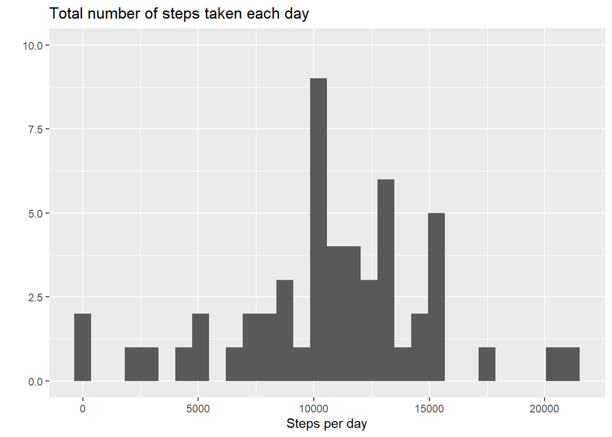

```r
sumbydate <- aggregate.data.frame(df$steps, by=list(df$date), FUN=sum)
library(ggplot2)
qplot(sumbydate$x, xlab = "Steps per day", ylim = c(0,10), main =
              "Total number of steps taken each day")
```

```r
mean <- mean(sumbydate$x, na.rm = TRUE)
median <- median(sumbydate$x, na.rm = TRUE)
```

## Section 3 - What is the average daily activity pattern?

1. Make a time series plot (i.e. type = “l”) of the 5-minute interval (x-axis) and the average number of steps taken, averaged across all days (y-axis)

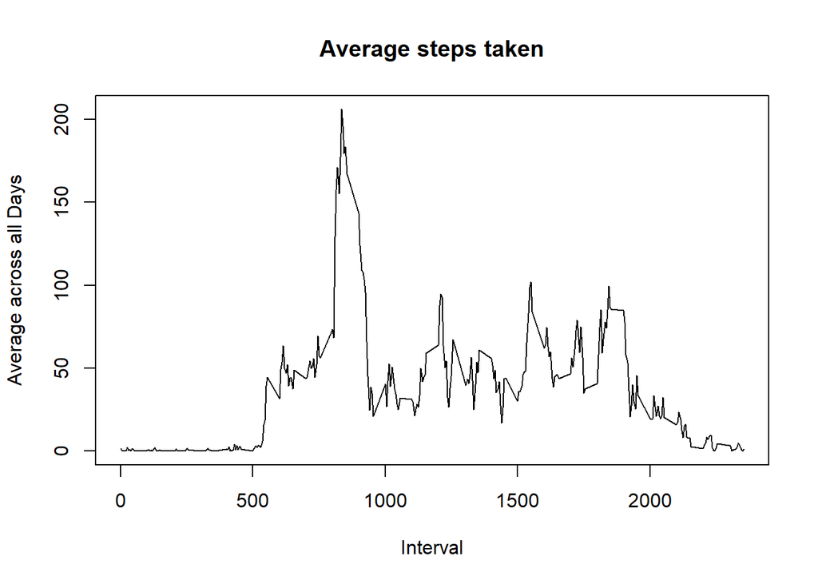

```r
time_series <- tapply(df$steps, df$interval, mean, na.rm = TRUE)
plot(row.names(time_series), time_series, type = "l", xlab = "Interval",
     ylab = "Average across all Days", main = "Average steps taken")
```

2. Which 5-minute interval, on average across all the days in the dataset, contains the maximum number of steps?

```r
max_interval <- which.max(time_series)
names(max_interval)
```

```
## [1] "835"
```

## Section 4 - Imputing missing values

1. Calculate and report the total number of missing values in the dataset (i.e. the total number of rows with NAs)

```r
sum(is.na(df))
```

```
## [1] 2304
```

2. Devise a strategy for filling in all of the missing values in the dataset. The strategy does not need to be sophisticated. For example, you could use the mean/median for that day, or the mean for that 5-minute interval, etc.
- I will replace the NAs with the mean for that 5- minute interval.
3. Create a new dataset that is equal to the original dataset but with the missing data filled in.

```r
rmNA_df <- df

for (i in which(sapply(rmNA_df, is.numeric))) {
     for (j in which(is.na(rmNA_df[, i]))) {
         rmNA_df[j, i] <- mean(rmNA_df[rmNA_df[, "interval"] == rmNA_df[j, "interval"], i],  na.rm = TRUE)
    }
}

str(df)
```

```
## 'data.frame':    17568 obs. of  3 variables:
##  $ steps   : int  NA NA NA NA NA NA NA NA NA NA ...
##  $ date    : Factor w/ 61 levels "2012-10-01","2012-10-02",..: 1 1 1 1 1 1 1 1 1 1 ...
##  $ interval: int  0 5 10 15 20 25 30 35 40 45 ...
```

```r
str(rmNA_df)
```

```
## 'data.frame':    17568 obs. of  3 variables:
##  $ steps   : num  1.717 0.3396 0.1321 0.1509 0.0755 ...
##  $ date    : Factor w/ 61 levels "2012-10-01","2012-10-02",..: 1 1 1 1 1 1 1 1 1 1 ...
##  $ interval: int  0 5 10 15 20 25 30 35 40 45 ...
```

[figure not shown]

```r
sumbydate <- aggregate.data.frame(rmNA_df$steps, by=list(rmNA_df$date), FUN=sum)
library(ggplot2)
qplot(sumbydate$x, xlab = "Steps per day", ylim = c(0,10), main =
              "Total number of steps taken each day")
```

```r
mean <- mean(sumbydate$x, na.rm = TRUE)
median <- median(sumbydate$x, na.rm = TRUE)
```